# Study 6 Analyses

NB referred to as Study 7 in manuscript

Ian Hussey & Jamie Cummins

09 March, 2021

# Notes

1. H2 and H3 from experiment 1 were discarded as they were not relevant to our questions in this experiment, but could notionally be assessed in retrospect (i.e., Correlation between online and offline measures of influence, Contribution of offline and online measures in predicting AMP effect sizes).

```r
# dependencies
library(tidyverse)
library(lme4)
library(sjPlot)
library(effects)
library(DescTools)
library(Rmisc)
library(effsize)
library(psych)
library(broom)
library(kableExtra)
# devtools::install_github("ianhussey/timesavers")
library(timesavers)  # for round_df()
library(plotrix)


# get data
task_level_data <- read.csv("../data/processed/processed_data.csv")

trial_level_amp_data <- read.csv("../data/processed/trial_level_amp_positive_negative_data.csv")

trial_level_ia_amp_data <- read.csv("../data/processed/trial_level_ia_amp_positive_negative_data.csv") %>%
  mutate(influenced = as.factor(influenced))


# exclusions
task_level_data_exclusions <- task_level_data %>%
  filter(self_exclusion_1 == "Yes, use my data" & complete_data == TRUE)

trial_level_amp_data_exclusions <- trial_level_amp_data %>%
  filter(self_exclusion_1 == "Yes, use my data" & complete_data == TRUE)

trial_level_ia_amp_data_exclusions <- trial_level_ia_amp_data %>%
  filter(self_exclusion_1 == "Yes, use my data" & complete_data == TRUE)
```

# Demographics

Analytic sample after exclusions.

```r
# Gender
task_level_data_exclusions %>%
  mutate(gender = tolower(gender)) %>%
  dplyr::count(gender)
```

```
##       gender  n
## 1          f  2
## 2     female 91
## 3    lady :)  1
## 4          m  1
## 5       male 55
## 6        man  1
## 7 non binary  1
## 8 non-binary  1
```

```r
# Age mean and SD
task_level_data_exclusions %>%
  mutate(age = as.numeric(as.character(age))) %>%
  summarise("age (mean)" = mean(age), "age (standard deviation)" = sd(age)) %>%
  round_df(2)
```

```
##   age (mean) age (standard deviation)
## 1      32.58                    10.86
```

# Manipulation checks

## M1: Demonstate an AMP effect on the AMP

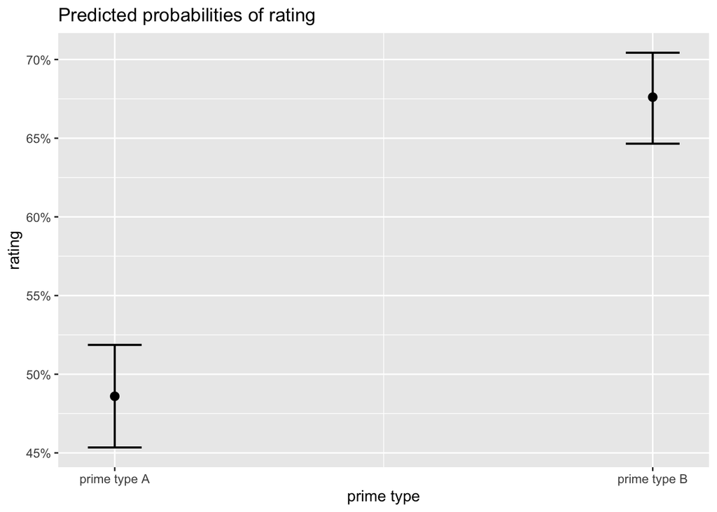

```r
# fit model
model_m1 <- glmer(rating ~ prime_type + (1 | subject),
                  family = binomial(link = "logit"),
                  data = trial_level_amp_data_exclusions)

# plot
plot_model(model_m1, type = "pred", terms = c("prime_type"))
```

```r
# results table
tab_model(model_m1, emph.p = FALSE, ci.hyphen = ", ")
```

|  | rating |  |  |
| --- | --- | --- | --- |
| Predictors | Odds Ratios | CI | p |
| (Intercept) | 0.95 | 0.83, 1.08 | 0.400 |
| prime_type [prime_type_B] | 2.21 | 2.04, 2.39 | <0.001 |
| Random Effects |  |  |  |
| σ<sup>2</sup> | 3.29 |  |  |
| τ<sub>00</sub> <sub>subject</sub> | 0.55 |  |  |
| ICC | 0.14 |  |  |
| N <sub>subject</sub> | 153 |  |  |
| Observations | 11016 |  |  |
| Marginal R<sup>2</sup> / Conditional R<sup>2</sup> | 0.039 / 0.178 |  |  |

## M2: Demonstate an AMP effect on the IA-AMP

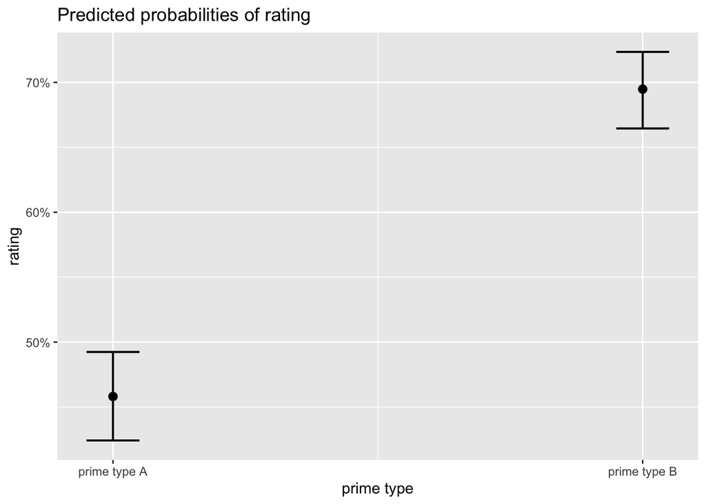

```r
# fit model
model_m2 <- glmer(rating ~ prime_type + (1 | subject),
                  family = binomial(link = "logit"),
                  data = trial_level_ia_amp_data_exclusions)

# plot
plot_model(model_m2, type = "pred", terms = c("prime_type"))
```

```r
# results table
tab_model(model_m2, emph.p = FALSE, ci.hyphen = ", ")
```

|  | rating |  |  |
| --- | --- | --- | --- |
| Predictors | Odds Ratios | CI | p |
| (Intercept) | 0.85 | 0.74, 0.97 | 0.017 |
| prime_type [prime_type_B] | 2.69 | 2.48, 2.92 | <0.001 |
| Random Effects |  |  |  |
| σ<sup>2</sup> | 3.29 |  |  |
| τ<sub>00</sub> <sub>subject</sub> | 0.62 |  |  |
| ICC | 0.16 |  |  |
| N <sub>subject</sub> | 153 |  |  |
| Observations | 11016 |  |  |
| Marginal R<sup>2</sup> / Conditional R<sup>2</sup> | 0.059 / 0.209 |  |  |

# Hypothesis tests

## H1: IA-AMP influence rate predicts IA-AMP effect

### H1a: at the trial level

Does conscious awareness of influence of the prime on the target moderate the AMP effect?

Key effect: influence*prime_type interaction

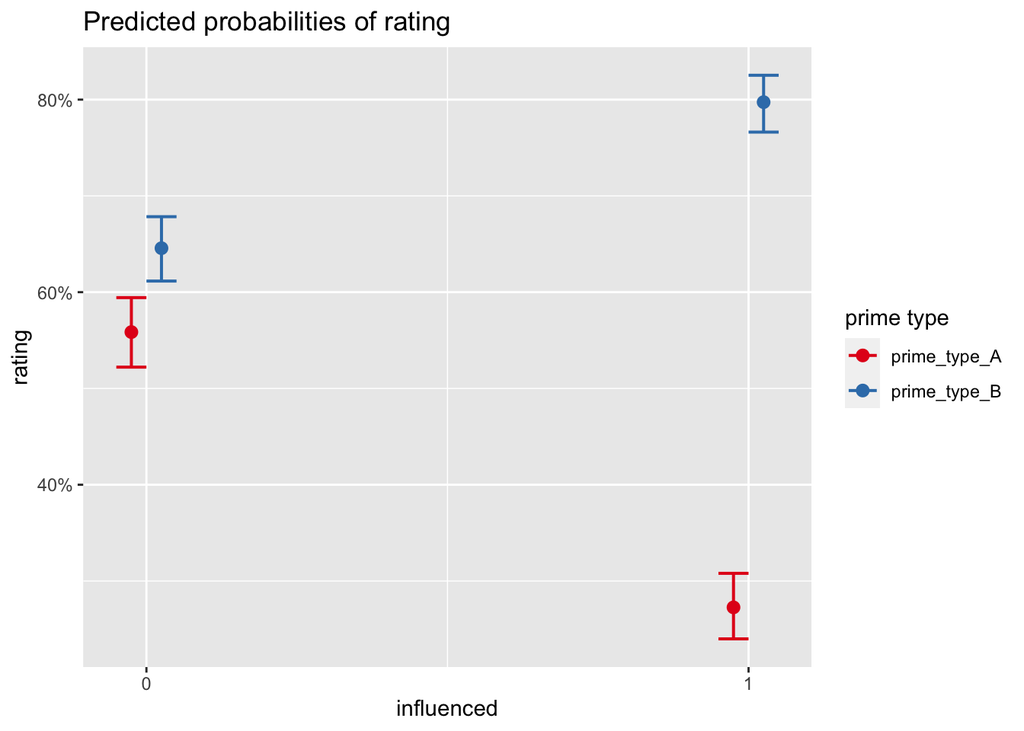

```r
# model
model_h1a <- glmer(rating ~ influenced * prime_type + (1 | subject),
                   family = binomial(link = "logit"),
                   data = trial_level_ia_amp_data_exclusions)

# plot
plot_model(model_h1a, type = "pred", terms = c("influenced", "prime_type"))
```

```r
# results table
tab_model(model_h1a, emph.p = FALSE, ci.hyphen = ", ")
```

|  | rating |  |  |
| --- | --- | --- | --- |
| Predictors | Odds Ratios | CI | p |
| (Intercept) | 1.27 | 1.09, 1.47 | 0.002 |
| influenced [1] | 0.30 | 0.26, 0.34 | <0.001 |
| prime_type [prime_type_B] | 1.44 | 1.30, 1.59 | <0.001 |
| influenced [1] * prime_type [prime_type_B] | 7.29 | 6.02, 8.83 | <0.001 |
| Random Effects |  |  |  |
| σ<sup>2</sup> | 3.29 |  |  |
| τ<sub>00</sub> <sub>subject</sub> | 0.63 |  |  |
| ICC | 0.16 |  |  |
| N <sub>subject</sub> | 153 |  |  |
| Observations | 11016 |  |  |
| Marginal R<sup>2</sup> / Conditional R<sup>2</sup> | 0.110 / 0.253 |  |  |

### H1b: at the participant level

Does rate of influence in the IA-AMP predict IA-AMP effects?

If effects in the IA-AMP are driven by intentional responding, then the size of the effect in the IA-AMP should be moderated by the subset of participants who are more often influenced by the primes.

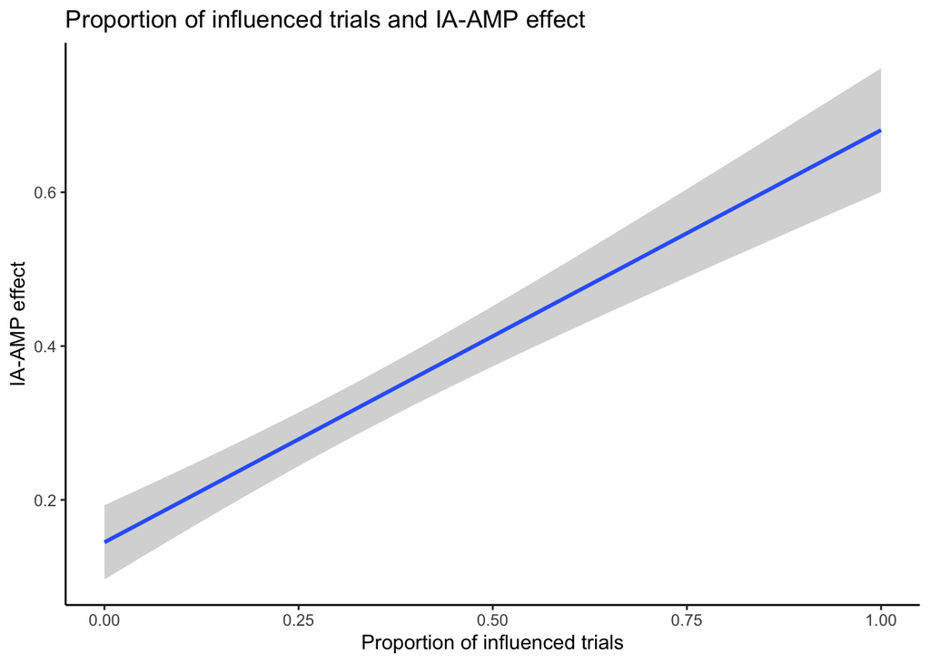

```r
# model
fit_h1b <- task_level_data_exclusions %>%
  mutate(abs_IA_AMP_effect_positive_negative = abs(IA_AMP_effect_positive_negative)) %>%
  lm(abs_IA_AMP_effect_positive_negative ~ influence_rate, data = .)

# plot
ggplot(task_level_data_exclusions, aes(influence_rate, abs(IA_AMP_effect_positive_negative))) +
  geom_smooth(method = lm) +
  labs(title = "Proportion of influenced trials and IA-AMP effect",
       x = "Proportion of influenced trials",
       y = "IA-AMP effect") +
  theme_classic()
```

```r
# results table
tab_model(fit_h1b, emph.p = FALSE, ci.hyphen = ", ", show.std = TRUE, col.order = c("est", "ci", "std.est", "std.ci", "p"))
```

|  | abs IA AMP effect positive negative |  |  |  |  |
| --- | --- | --- | --- | --- | --- |
| Predictors | Estimates | CI | std. Beta | standardized CI | p |
| (Intercept) | 0.14 | 0.10, 0.19 | 0.00 | -0.12, 0.12 | <0.001 |
| influence_rate | 0.54 | 0.43, 0.64 | 0.63 | 0.50, 0.75 | <0.001 |
| Observations | 153 |  |  |  |  |
| R<sup>2</sup> / R<sup>2</sup> adjusted | 0.393 / 0.389 |  |  |  |  |

## H2: IA-AMP influence rate predicts the absolute magnitude of the standard AMP effect

If effects in the standard AMP, as well as the IA-AMP, are driven by participants who are more often influenced, then rate of influence in the IA-AMP should predict effect sizes in the standard AMP.

Because the AMP is completed prior to the IA AMP, if the IA AMP’s influence rate predicts the (previously completed) AMP’s effect then this implies that 1) measuring the influence rate does not perturb the IA AMP effect, and 2) that the rate of influence is reliable within participants across AMP/IA AMPs.

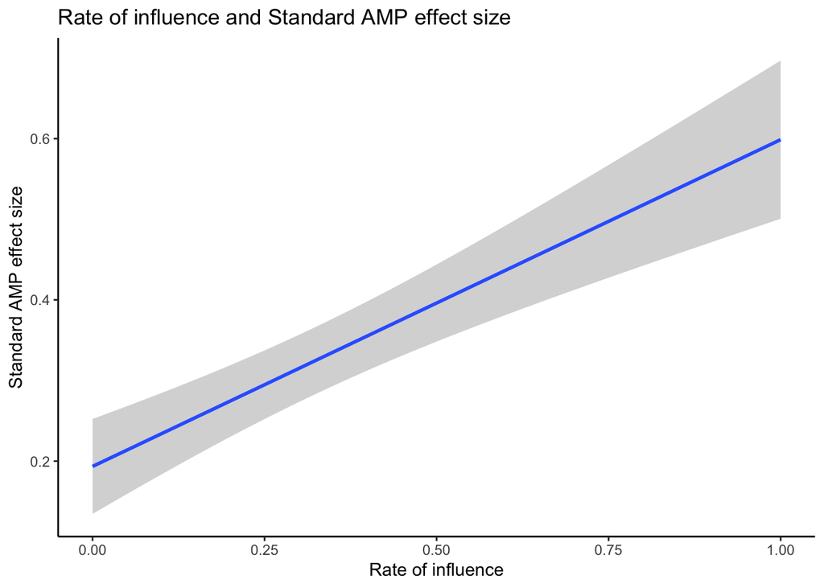

```r
# model
fit_h2 <- task_level_data_exclusions %>%
  mutate(abs_AMP_effect_positive_negative = abs(AMP_effect_positive_negative)) %>%
  lm(abs_AMP_effect_positive_negative ~ influence_rate, data = .)

# plot
ggplot(task_level_data_exclusions, aes(influence_rate, abs(AMP_effect_positive_negative))) +
  geom_smooth(method = lm) +
  labs(title = "Rate of influence and Standard AMP effect size",
       x = "Rate of influence",
       y = "Standard AMP effect size") +
  theme_classic()
```

```r
# table
tab_model(fit_h2, emph.p = FALSE, ci.hyphen = ", ", show.std = TRUE, col.order = c("est", "ci", "std.est", "std.ci", "p"))
```

|  | abs AMP effect positive negative |  |  |  |  |
| --- | --- | --- | --- | --- | --- |
| Predictors | Estimates | CI | std. Beta | standardized CI | p |
| (Intercept) | 0.19 | 0.13, 0.25 | 0.00 | -0.14, 0.14 | <0.001 |
| influence_rate | 0.41 | 0.27, 0.54 | 0.45 | 0.30, 0.59 | <0.001 |
| Observations | 153 |  |  |  |  |
| R<sup>2</sup> / R<sup>2</sup> adjusted | 0.199 / 0.194 |  |  |  |  |